# Building and tuning ensemble models with MLR. Boston housing example.

Gleb Zakhodyakin, postlogist@gmail.com

07.06.2021

```r
library(MASS) #stepwise regression
library(mlr) # Machine Learning framework for R
library(stringr) # string processing
library(parallelMap) # Parallel computation
library(rpart.plot) # Visualization of rpart trees
library(tidyverse) # Data visualization and transformation
library(ggfortify) # Diagnostic plots for lm
library(GGally) # SPLOM
```

# Introduction

This tutorial shows how to build and to tune parameters for ensemble models using the mlr framework. We’ll compare the performance of different types of regression models in the task of predicting median house price in Boston.

# Exploring the data

Loading the Boston dataset. See ?Boston

```r
data(Boston)
head(Boston)
```

| crim | zn | indus | chas | nox | rm | age | dis | rad | tax | ptratio | black | lstat | medv |
| --- | --- | --- | --- | --- | --- | --- | --- | --- | --- | --- | --- | --- | --- |
| 0.00632 | 18 | 2.31 | 0 | 0.538 | 6.575 | 65.2 | 4.0900 | 1 | 296 | 15.3 | 396.90 | 4.98 | 24.0 |
| 0.02731 | 0 | 7.07 | 0 | 0.469 | 6.421 | 78.9 | 4.9671 | 2 | 242 | 17.8 | 396.90 | 9.14 | 21.6 |
| 0.02729 | 0 | 7.07 | 0 | 0.469 | 7.185 | 61.1 | 4.9671 | 2 | 242 | 17.8 | 392.83 | 4.03 | 34.7 |
| 0.03237 | 0 | 2.18 | 0 | 0.458 | 6.998 | 45.8 | 6.0622 | 3 | 222 | 18.7 | 394.63 | 2.94 | 33.4 |
| 0.06905 | 0 | 2.18 | 0 | 0.458 | 7.147 | 54.2 | 6.0622 | 3 | 222 | 18.7 | 396.90 | 5.33 | 36.2 |
| 0.02985 | 0 | 2.18 | 0 | 0.458 | 6.430 | 58.7 | 6.0622 | 3 | 222 | 18.7 | 394.12 | 5.21 | 28.7 |

A quick look on the variable correlations:

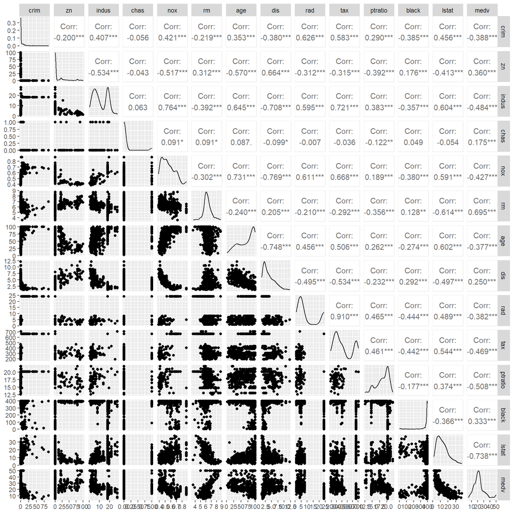

```r
ggpairs(Boston)
```

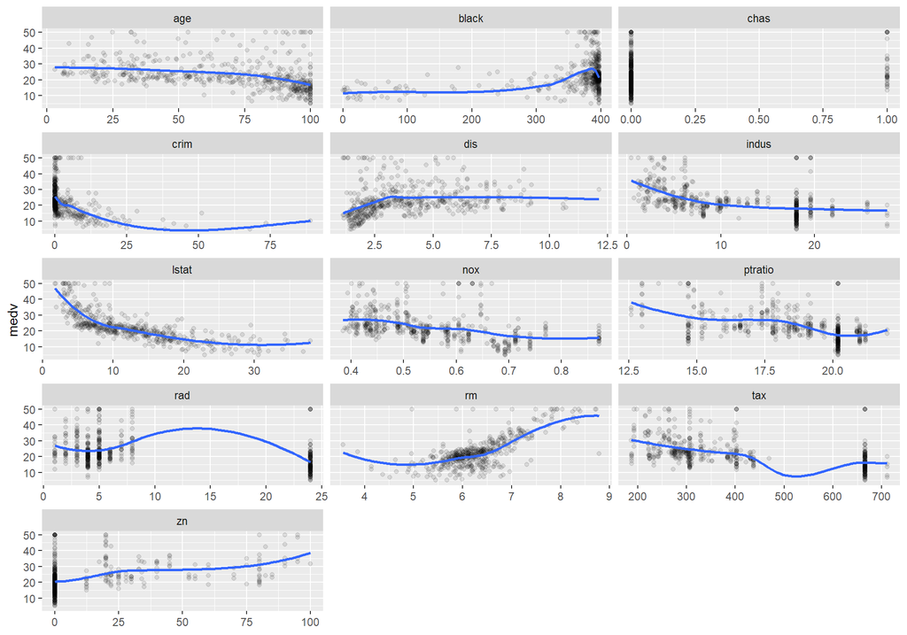

```r
Boston %>% gather(key = 'variable', value = 'value', -medv) %>%
  ggplot(aes(value, medv)) +
  geom_point(alpha = 0.1) +
  geom_smooth(se = F) +
  facet_wrap(~variable, scales = "free_x", ncol = 3) +
  labs(x = NULL)
```

From the plots we can see, that some variables have a non-linear relationship to the target variable `medv`. We can incorporate them into the regression model by adding non-linear terms.

A quadratic term might be useful for `black`, `crim`, `indus`, `lstat`, `rm` variables. `dis` might require a square root or logarithmic term.

```r
m_boston_full <- lm(medv ~ . + I(black^2)+ I(crim^2) + I(indus^2) +
                      I(lstat^2)  + I(rm^2) + sqrt(dis),
                    , data = Boston)
summary(m_boston_full)
```

```
##
## Call:
## lm(formula = medv ~ . + I(black^2) + I(crim^2) + I(indus^2) +
##     I(lstat^2) + I(rm^2) + sqrt(dis), data = Boston)
##
## Residuals:
##      Min       1Q   Median       3Q      Max
## -26.8206  -2.0984  -0.2216   1.9039  23.7631
##
## Coefficients:
##               Estimate Std. Error t value Pr(>|t|)
## (Intercept)  1.320e+02  1.005e+01  13.136  < 2e-16 ***
## crim        -4.147e-01  8.406e-02  -4.933 1.11e-06 ***
## zn           5.348e-03  1.251e-02   0.427 0.669245
## indus       -1.546e-01  1.573e-01  -0.983 0.326192
## chas         2.372e+00  7.129e-01   3.328 0.000942 ***
## nox         -2.203e+01  3.357e+00  -6.560 1.38e-10 ***
## rm          -1.973e+01  2.771e+00  -7.121 3.88e-12 ***
## age          1.402e-03  1.158e-02   0.121 0.903723
## dis          2.282e+00  8.734e-01   2.613 0.009259 **
## rad          3.950e-01  6.247e-02   6.323 5.80e-10 ***
## tax         -1.342e-02  3.131e-03  -4.287 2.18e-05 ***
## ptratio     -7.237e-01  1.088e-01  -6.653 7.77e-11 ***
## black        2.408e-02  1.095e-02   2.200 0.028263 *
## lstat       -1.259e+00  1.276e-01  -9.866  < 2e-16 ***
## I(black^2)  -4.181e-05  2.401e-05  -1.741 0.082285 .
## I(crim^2)    3.348e-03  1.081e-03   3.096 0.002071 **
## I(indus^2)   6.864e-03  5.645e-03   1.216 0.224662
## I(lstat^2)   2.099e-02  3.431e-03   6.118 1.95e-09 ***
## I(rm^2)      1.804e+00  2.165e-01   8.332 8.21e-16 ***
## sqrt(dis)   -1.541e+01  3.893e+00  -3.959 8.64e-05 ***
## ---
## Signif. codes:  0 '***' 0.001 '**' 0.01 '*' 0.05 '.' 0.1 ' ' 1
##
## Residual standard error: 3.877 on 486 degrees of freedom
## Multiple R-squared:  0.829,  Adjusted R-squared:  0.8223
## F-statistic:   124 on 19 and 486 DF,  p-value: < 2.2e-16
```

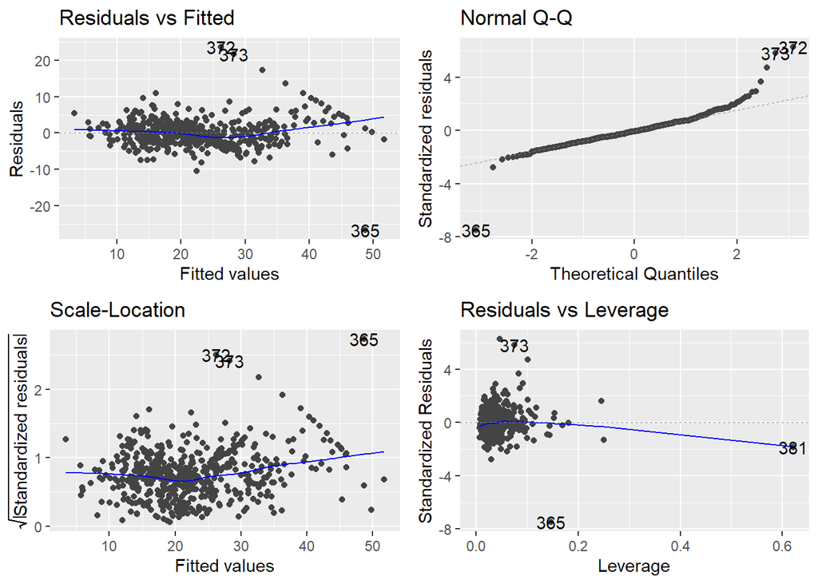

```r
autoplot(m_boston_full)
```

There’s still some non-linearity in the residuals, as well as a strange trail of points at the right hand side, but overall the model fits quite good. Some variables are not significant. We can deal with this later using variable selection techniques such as Lasso.

# Building and comparing the models with mlr

## Multiple regression and Lasso

First, we create a learning task for multiple regression. We need to add the non-linear terms as separate variables

```r
tsk_Boston_Poly <-
  Boston %>%
  mutate(black2 = black^2,
         crim2 = crim^2,
         indus2 = indus^2,
         lstat2 = lstat^2,
         rm2 = rm^2,
         sqrtdis = sqrt(dis)) %>%
  makeRegrTask(id = "Boston Housing (with polynomials)", target = "medv", data = .) %>%
  normalizeFeatures(method='standardize')
```

Next, we create two regression-based learners:

```r
# Multiple regression
lrn_mlr <- makeLearner("regr.lm", id = "mlr")

# Lasso regression
lrn_lasso <- makeLearner("regr.glmnet", id = "Lasso",
                         par.vals = list(alpha = 1))
```

Creating a list of performance metrics:

```r
# A list of model performance metrics for regression
ms_regr = list(mape, mse, timetrain, mae, rmse, rsq)
```

Creating a resampling description for 10-fold cross-validation:

```r
rdesc_CV10 <-
  makeResampleDesc(method = "CV", iter = 10)
```

Detecting the number of available CPU cores

```r
# Detecting the number of avaliable CPU cores
num_cores <- parallel::detectCores()
```

Now we can benchmark the models:

```r
# Setting the random number generator for reproducibility
set.seed(123, "L'Ecuyer")

# Starting parallelization
parallelStartSocket(num_cores)
```

```
## Starting parallelization in mode=socket with cpus=16.
```

```r
bench_Boston_Baseline <-
  list(lrn_mlr, lrn_lasso) %>%
  benchmark(learners = .,
            tasks = tsk_Boston_Poly,
            resampling = rdesc_CV10,
          measures = ms_regr,
         show.info = TRUE)
```

```
## Exporting objects to slaves for mode socket: .mlr.slave.options
```

```
## Mapping in parallel: mode = socket; level = mlr.benchmark; cpus = 16; elements = 2.
```

```r
parallelStop()
```

```
## Stopped parallelization. All cleaned up.
```

Here we define a helper function to automatically print benchmarks sorted by MAPE.

```r
printBenchmark <- function(benchmarkResults) {
  benchmarkResults %>%
  getBMRAggrPerformances(as.df = TRUE) %>%
  arrange(mape.test.mean) %>%
  dplyr::select(-task.id) %>%
  mutate_if(is.numeric, round, digits = 3)
}
```

```r
bench_Boston_Baseline %>%
  printBenchmark()
```

| learner.id | mape.test.mean | mse.test.mean | timetrain.test.mean | mae.test.mean | rmse.test.rmse | rsq.test.mean |
| --- | --- | --- | --- | --- | --- | --- |
| Lasso | 0.140 | 16.843 | 0.002 | 2.802 | 4.104 | 0.784 |
| mlr | 0.142 | 16.940 | 0.004 | 2.822 | 4.116 | 0.780 |

## Tree-based models

Now we compare two tree-based models - CART and Conditional Inference Tree. These models will be trained on the original dataset, since trees can learn non-linear relationships automatically.

Creating a learning task for the original dataset.

```r
tsk_Boston <- makeRegrTask(id = "Boston Housing", target = "medv", data = Boston)
```

Creating tree-based learners

```r
lrn_rpart <- makeLearner("regr.rpart", id = "rpart")
lrn_ctree <- makeLearner("regr.ctree", id = "ctree")
```

```r
# Setting the random number generator for reproducibility
set.seed(123, "L'Ecuyer")

# Starting parallelization
parallelStartSocket(num_cores)
```

```
## Starting parallelization in mode=socket with cpus=16.
```

```r
bench_Boston_Trees <-
  list(lrn_rpart, lrn_ctree) %>%
  benchmark(learners = .,
            tasks = tsk_Boston,
            resampling = rdesc_CV10,
            measures = ms_regr,
            show.info = TRUE)
```

```
## Exporting objects to slaves for mode socket: .mlr.slave.options
```

```
## Mapping in parallel: mode = socket; level = mlr.benchmark; cpus = 16; elements = 2.
```

```r
parallelStop()
```

```
## Stopped parallelization. All cleaned up.
```

Benchmark results:

```r
bench_Boston_Trees %>%
  printBenchmark()
```

| learner.id | mape.test.mean | mse.test.mean | timetrain.test.mean | mae.test.mean | rmse.test.rmse | rsq.test.mean |
| --- | --- | --- | --- | --- | --- | --- |
| ctree | 0.145 | 19.094 | 0.011 | 2.914 | 4.370 | 0.765 |
| rpart | 0.166 | 20.859 | 0.004 | 3.137 | 4.567 | 0.737 |

Ctree yielded a model comparable in performance to multiple regression, rpart produced a worse model, since it prefers more conservative trees with the default parameters.

## Ensemble models

Now we compare a few ensemble-based models - bagging, Random Forest, and boosting. Bagging is implemented using `randomForest()` function with `mtry` parameter set to the number of predictors.

```r
lrn_bagging_Boston <-
  makeLearner("regr.randomForest", id="Bagging (via RF)",
              mtry = getTaskNFeats(tsk_Boston))

lrn_RF_Boston <-
  makeLearner("regr.randomForest", id="randomForest")

lrn_ranger_Boston <-
  makeLearner("regr.ranger", id="ranger")

lrn_cforest_Boston <-
  makeLearner("regr.cforest", id="cforest")

lrn_gbm_Boston <-
  makeLearner("regr.gbm", id="gbm")


lrn_xgboost_Boston <-
  makeLearner("regr.xgboost", id="xgboost")
```

Benchmarking the models

```r
# Setting the random number generator for reproducibility
set.seed(123, "L'Ecuyer")

# Starting parallelization
parallelStartSocket(num_cores)
```

```
## Starting parallelization in mode=socket with cpus=16.
```

```r
bench_Boston_Ensembles <-
  list(lrn_bagging_Boston, lrn_RF_Boston,
                            lrn_ranger_Boston, lrn_cforest_Boston,
                            lrn_gbm_Boston, lrn_xgboost_Boston) %>%
  benchmark(learners = .,
            tasks = tsk_Boston,
            resampling = rdesc_CV10,
            measures = ms_regr,
           show.info = TRUE)
```

```
## Exporting objects to slaves for mode socket: .mlr.slave.options
```

```
## Mapping in parallel: mode = socket; level = mlr.benchmark; cpus = 16; elements = 6.
```

```r
parallelStop()
```

```
## Stopped parallelization. All cleaned up.
```

Comparing the results

```r
bench_Boston_Ensembles %>%
  printBenchmark()
```

| learner.id | mape.test.mean | mse.test.mean | timetrain.test.mean | mae.test.mean | rmse.test.rmse | rsq.test.mean |
| --- | --- | --- | --- | --- | --- | --- |
| randomForest | 0.108 | 10.245 | 0.376 | 2.141 | 3.201 | 0.874 |
| ranger | 0.110 | 10.943 | 0.157 | 2.179 | 3.308 | 0.866 |
| Bagging (via RF) | 0.112 | 10.352 | 0.903 | 2.204 | 3.217 | 0.864 |
| cforest | 0.127 | 14.999 | 0.555 | 2.538 | 3.873 | 0.818 |
| gbm | 0.131 | 14.697 | 0.021 | 2.592 | 3.834 | 0.816 |
| xgboost | 0.678 | 294.631 | 0.009 | 15.601 | 17.165 | -2.657 |

Most ensembles produced a better result compared to single trees and regression. The xgboost algorithm has overfit the data and showed poor results in cross validation. Boosting-based algorithms were the fastest to train. Ranger is ~2 times faster on this task compared to randomForest

# Tuning the hyperparameters

The xgboost algorithm has a large set of parameters:

```r
lrn_xgboost_Boston %>%
  getLearnerParamSet()
```

```
##                                 Type  len             Def                               Constr Req
## booster                     discrete    -          gbtree                 gbtree,gblinear,dart   -
## watchlist                    untyped    -          <NULL>                                    -   -
## eta                          numeric    -             0.3                               0 to 1   -
## gamma                        numeric    -               0                             0 to Inf   -
## max_depth                    integer    -               6                             0 to Inf   -
## min_child_weight             numeric    -               1                             0 to Inf   -
## subsample                    numeric    -               1                               0 to 1   -
## colsample_bytree             numeric    -               1                               0 to 1   -
## colsample_bylevel            numeric    -               1                               0 to 1   -
## colsample_bynode             numeric    -               1                               0 to 1   -
## num_parallel_tree            integer    -               1                             1 to Inf   -
## lambda                       numeric    -               1                             0 to Inf   -
## lambda_bias                  numeric    -               0                             0 to Inf   -
## alpha                        numeric    -               0                             0 to Inf   -
## objective                    untyped    - reg:squarede...                                    -   -
## eval_metric                  untyped    -            rmse                                    -   -
## base_score                   numeric    -             0.5                          -Inf to Inf   -
## max_delta_step               numeric    -               0                             0 to Inf   -
## missing                      numeric    -                                          -Inf to Inf   -
## monotone_constraints   integervector <NA>               0                              -1 to 1   -
## tweedie_variance_power       numeric    -             1.5                               1 to 2   Y
## nthread                      integer    -               -                             1 to Inf   -
## nrounds                      integer    -               -                             1 to Inf   -
## feval                        untyped    -          <NULL>                                    -   -
## verbose                      integer    -               1                               0 to 2   -
## print_every_n                integer    -               1                             1 to Inf   Y
## early_stopping_rounds        integer    -          <NULL>                             1 to Inf   -
## maximize                     logical    -          <NULL>                                    -   -
## sample_type                 discrete    -         uniform                     uniform,weighted   Y
## normalize_type              discrete    -            tree                          tree,forest   Y
## rate_drop                    numeric    -               0                               0 to 1   Y
## skip_drop                    numeric    -               0                               0 to 1   Y
## scale_pos_weight             numeric    -               1                          -Inf to Inf   -
## refresh_leaf                 logical    -            TRUE                                    -   -
## feature_selector            discrete    -          cyclic cyclic,shuffle,random,greedy,thrifty   -
## top_k                        integer    -               0                             0 to Inf   -
## predictor                   discrete    -   cpu_predictor          cpu_predictor,gpu_predictor   -
## updater                      untyped    -               -                                    -   -
## sketch_eps                   numeric    -            0.03                               0 to 1   -
```

[output cut: 37 more lines]

```
## rate_drop                 TRUE     -
## skip_drop                 TRUE     -
## scale_pos_weight          TRUE     -
## refresh_leaf              TRUE     -
## feature_selector          TRUE     -
## top_k                     TRUE     -
## predictor                 TRUE     -
## updater                   TRUE     -
## sketch_eps                TRUE     -
## one_drop                  TRUE     -
## tree_method               TRUE     -
## grow_policy               TRUE     -
## max_leaves                TRUE     -
## max_bin                   TRUE     -
## callbacks                FALSE     -
```

The description of the parameters is available in the help or [online](https://xgboost.readthedocs.io/en/latest/parameter.html).

To control overfitting, we can limit the minimum node size, the maximum tree depth, the minimum improvement in node purity, the learning rate and the number of boosting rounds. Additionally, we can adjust the proportions of sampled observations and variables for training a tree.

```r
ps_xgb <- makeParamSet(
         makeIntegerParam("max_depth",lower = 1L,upper = 6L), # maximum tree depth - controls the interactions
         makeIntegerParam("nrounds",lower = 1L,upper = 2000L), # maximum number of trees to build
         makeNumericParam("min_child_weight",lower = 1L,upper = 10L), #minimum node size
         makeNumericParam("subsample",lower = 0.5,upper = 1), #proportion of sampled observations for training
         makeNumericParam("colsample_bytree",lower = 0.5,upper = 1),   #proportion of sampled variables
         makeNumericParam("eta",lower = -3, upper = -0.5, trafo = function(x){10^x}) # learning rate

)
```

To speed-up computation, we’ll add the resample description for 5-fold cross-validation.

```r
rdesc_CV5 <- makeResampleDesc(method = "CV",iter = 5)
```

We can use different search algorithms to find the optimal combination of parameters.

The `GenSA` algorithm uses [simulated annealing](https://en.wikipedia.org/wiki/Simulated_annealing) search strategy, but can be slow and hard to control.

The function takes limits for maximum number of objective evaluations (`budget`), the maximum number of search iterations (`maxit`) and maximum time for running (in seconds), but the current implementation fails to enforce them, so the actual running time might be much larger.

```r
ctrl <- makeTuneControlGenSA(budget = 25, maxit = 25, max.time = 300)
```

We can also employ random search, which just checks a given number of randomly selected combinations of parameters (`maxit`).

```r
#ctrl <- makeTuneControlRandom(maxit = 100)
```

To prevent very large report knitting time, we also cache the optimized parameters in a file. The search will be only performed when that file is absent.

Here we perform the hyperparameter tuning:

```r
set.seed(123, "L'Ecuyer")

fname <- "xgboost_tune_Boston.RDS"

if (file.exists(fname)) {
  xgboost_tune_Boston <- readRDS(fname)
} else {
  parallelStartSocket(num_cores)

  xgboost_tune_Boston <-
    tuneParams(
      learner = lrn_xgboost_Boston,
      task = tsk_Boston,
      resampling = rdesc_CV5,
      measures = mape,
      par.set = ps_xgb,
      control = ctrl,
      show.info = T
    )

  parallelStop()
  saveRDS(xgboost_tune_Boston, file = fname)
}
```

Review the optimized parameter values:

```r
xgboost_tune_Boston$y
```

```
## mape.test.mean
##        0.10507
```

```r
xgboost_tune_Boston$x
```

```
## $max_depth
## [1] 5
##
## $nrounds
## [1] 1391
##
## $min_child_weight
## [1] 2.713692
##
## $subsample
## [1] 0.8673025
##
## $colsample_bytree
## [1] 0.9505431
##
## $eta
## [1] 0.01091623
```

Make a new learner with adjusted hyperparameters:

```r
lrn_xgboost_tuned_Boston <-
  makeLearner("regr.xgboost", id = "xgboost, tuned") %>%
  setHyperPars(par.vals = xgboost_tune_Boston$x)
```

Benchmark the new learner:

```r
# Setting the random number generator for reproducibility
set.seed(123, "L'Ecuyer")

# Starting parallelization
parallelStartSocket(num_cores)
```

```
## Starting parallelization in mode=socket with cpus=16.
```

```r
bench_Boston_ensembles <-
   list(lrn_xgboost_Boston, lrn_xgboost_tuned_Boston) %>%
  benchmark(
    learners = .,
    tasks = tsk_Boston,
    resampling = rdesc_CV10,
    measures = ms_regr,
    show.info = TRUE)
```

```
## Exporting objects to slaves for mode socket: .mlr.slave.options
```

```
## Mapping in parallel: mode = socket; level = mlr.benchmark; cpus = 16; elements = 2.
```

```r
parallelStop()
```

```
## Stopped parallelization. All cleaned up.
```

Compare the performance:

```r
bench_Boston_ensembles %>%
  printBenchmark()
```

| learner.id | mape.test.mean | mse.test.mean | timetrain.test.mean | mae.test.mean | rmse.test.rmse | rsq.test.mean |
| --- | --- | --- | --- | --- | --- | --- |
| xgboost, tuned | 0.100 | 8.562 | 2.885 | 1.973 | 2.926 | 0.888 |
| xgboost | 0.678 | 294.631 | 0.007 | 15.601 | 17.165 | -2.657 |

# Feature importance

The ensemble models are hard to interpret due to large number of trees in the ensemble. We can however get the information on variable importance which is similar to the summary of a regression model.

The relative importance is based on the average improvement in node purity when doing a split on a particular predictor.

First, we need to train an ensemble model (xgboost in this case):

```r
m_xgboost_Boston <-
  lrn_xgboost_tuned_Boston %>%
  train(tsk_Boston)
```

The `featureImportance()` function extracts the variable importance metrics from the trained model. Some learning algorithms need parameter adjustments to produce that data. Refer to [help](https://mlr.mlr-org.com/reference/getFeatureImportance.html) to learn more.

```r
fi_xgboost <-
  m_xgboost_Boston %>%
  getFeatureImportance()
```

```r
names(fi_xgboost)
```

```
## [1] "res"         "task.desc"   "learner"     "measure"     "contrast"    "aggregation"
## [7] "nmc"         "replace"     "local"
```

The extracted feature importance are stored in the `res` element of the object produced by the function. Here we extract it and visualize using `ggplot()`.

It is a good idea to create a helper function to plot the feature importance:

```r
plotFeatureImportance <- function(fi_data) {
  fi_data$res %>%
  gather(key = 'variable', value = 'importance') %>%
  arrange(desc(importance)) %>%
  ggplot(aes(fct_reorder(variable, importance), importance)) +
  geom_col() +
  coord_flip()
}
```

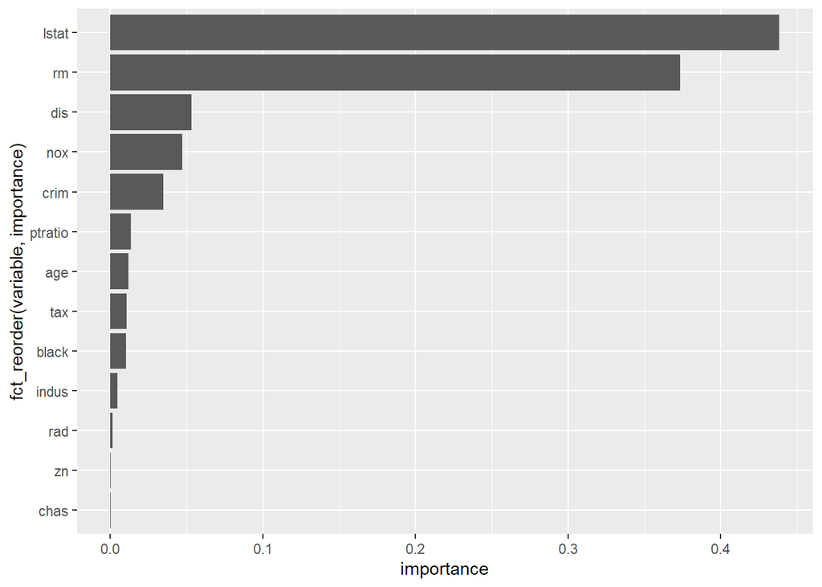

```r
fi_xgboost %>%
  plotFeatureImportance()
```

A similar plot can be costructed for the Random Forest model:

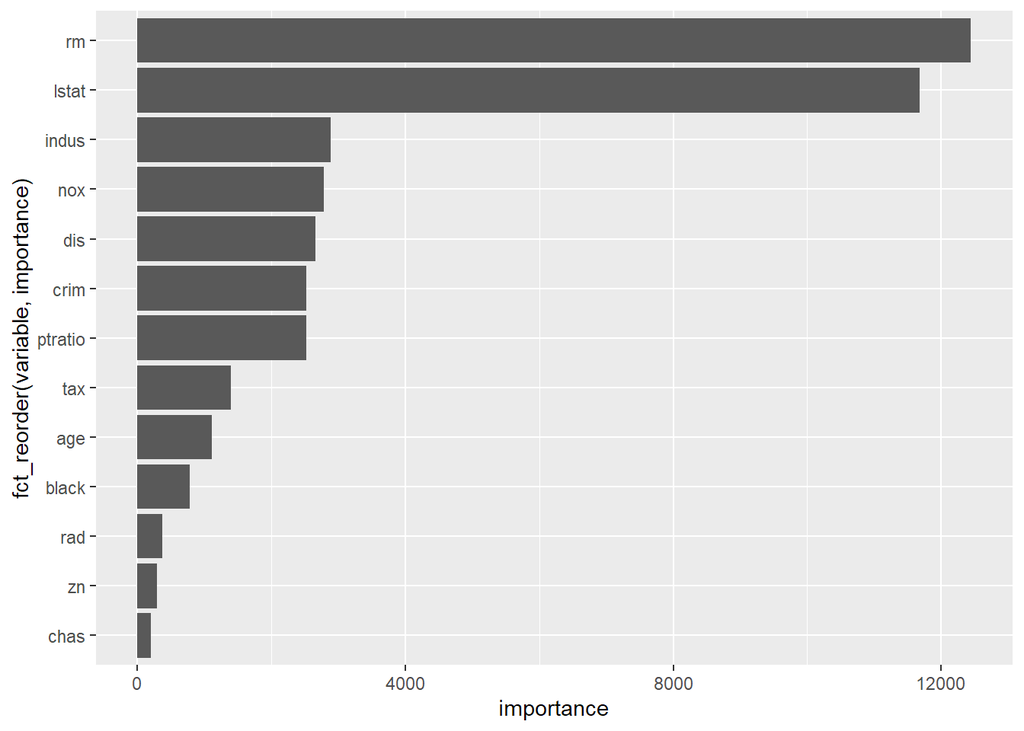

```r
m_RF_Boston <-
  lrn_RF_Boston %>%
  train(tsk_Boston)

m_RF_Boston %>%
  getFeatureImportance() %>%
  plotFeatureImportance()
```

# Partial dependence plots

[Partial dependence plots](https://christophm.github.io/interpretable-ml-book/ice.html) provide additional insight into the complex ensemble model. Such a plot shows how would the target variable change when changing as single predictor or a pair of predictors keeping all the remaining predictors fixed. This is similar to multiple regression coefficients, but the influence of a predictor is not constant and not linear.

There’s a built-in functionality in mlr to construct such plots.

First, we consider individual effects of each predictor.

Generating data for the individual plots:

```r
pd_xgboost_Boston_individual <-
  m_xgboost_Boston %>%
  generatePartialDependenceData(tsk_Boston,
                                features = c("rm", "lstat", "ptratio", "nox",
                                             "dis", "indus", "crim", "tax",
                                             "age", "black", "chas",
                                             "rad", "zn")
                                )
pd_xgboost_Boston_individual
```

```
## PartialDependenceData
## Task: Boston Housing
## Features: rm, lstat, ptratio, nox, dis, indus, crim, tax, age, black, chas, rad, zn
## Target: rm, lstat, ptratio, nox, dis, indus, crim, tax, age, black, chas, rad, zn
## Derivative: FALSE
## Interaction: FALSE
## Individual: FALSE
##        medv       rm lstat ptratio nox dis indus crim tax age black chas rad zn
## 1: 19.88553 3.561000    NA      NA  NA  NA    NA   NA  NA  NA    NA   NA  NA NA
## 2: 19.88553 4.140889    NA      NA  NA  NA    NA   NA  NA  NA    NA   NA  NA NA
## 3: 19.97952 4.720778    NA      NA  NA  NA    NA   NA  NA  NA    NA   NA  NA NA
## 4: 19.41920 5.300667    NA      NA  NA  NA    NA   NA  NA  NA    NA   NA  NA NA
## 5: 19.94604 5.880556    NA      NA  NA  NA    NA   NA  NA  NA    NA   NA  NA NA
## 6: 21.14735 6.460444    NA      NA  NA  NA    NA   NA  NA  NA    NA   NA  NA NA
## ... (#rows: 122, #cols: 14)
```

Plotting individual predictor effects:

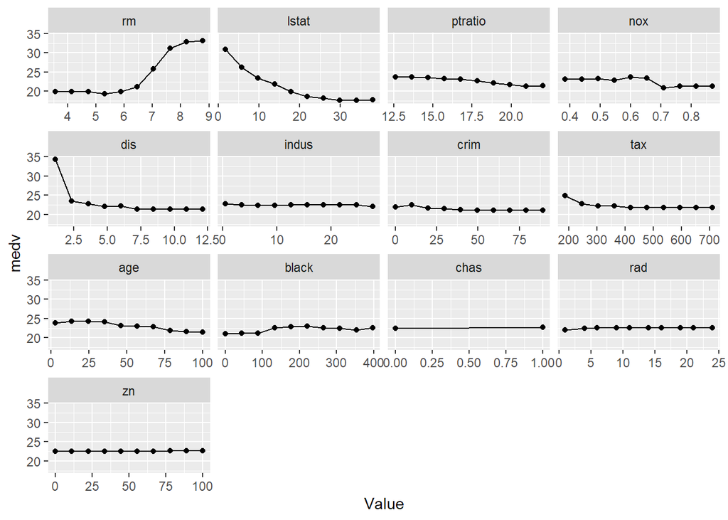

```r
pd_xgboost_Boston_individual %>%
  plotPartialDependence()
```

We can also consider the effect from a pair of predictors. Such a plot may reveal an interaction between them.

Generating data:

```r
pd_xgboost_Boston_interact <-
  m_xgboost_Boston %>%
  generatePartialDependenceData(tsk_Boston,
                                features = c("rm", "indus"),
                                interaction = T # enable interactions
                                )
```

To visualize the effect from two predictors, we extract the resulting dataset (`data` element) and create a heatmap using `ggplot()`.

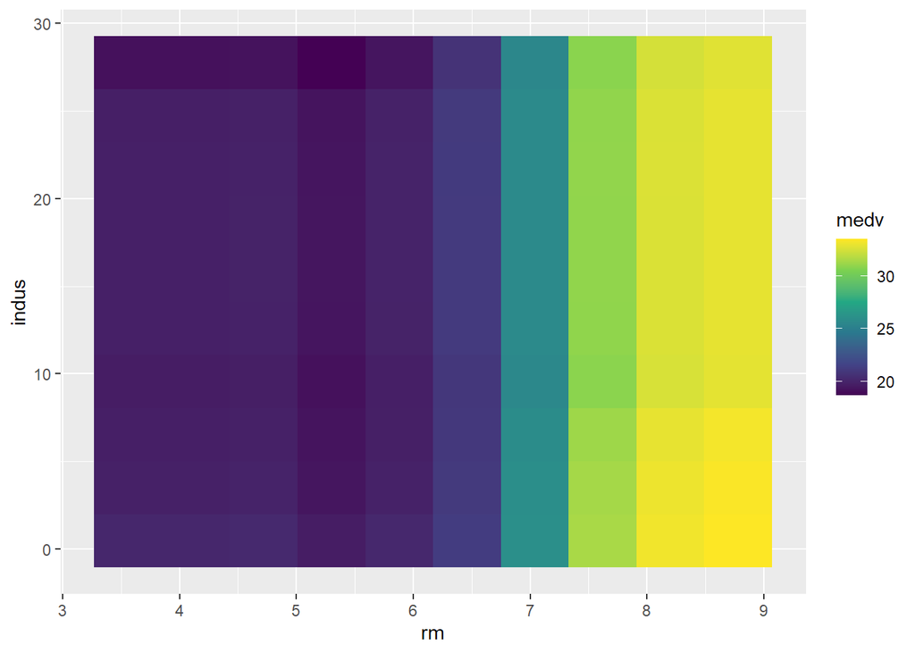

```r
pd_xgboost_Boston_interact %>%
  .$data %>%
  ggplot(aes(rm, indus, fill = medv)) +
  geom_tile() +
  scale_fill_viridis_c()
```

You can find more examples in [this tutorial](https://mlr.mlr-org.com/articles/tutorial/partial_dependence.html)